# One Variable: Qualitative

Author

Orville D. Hombrebueno

Published

October 1, 2026

# The Data

```r
# load packages
library(tidyverse)
library(knitr)
library(gtsummary)
library(ggstatsplot)
library(downlit)
library(broom)

# load the data
titanic <- ggstatsplot::Titanic_full |>
  mutate(
    Class = factor(Class)
  )
```

## The Titanic Data Set

The `Titanic_full` data set of the {ggstatsplot} package is a data frame with 2201 rows and 5 variables.

- id. Dummy identity number for each person.
- Class. 1st, 2nd, 3rd, Crew.
- Sex. Male, Female.
- Age. Child, Adult.
- Survived. No, Yes.

This data set provides information on the fate of passengers on the fatal maiden voyage of the ocean liner Titanic, summarized according to economic status (class), sex, age and survival.

The first 6 rows of the titanic data set are shown in Table 1.

```r
titanic |>
  head() |> # getting the first six rows of the data
  kable() # creating a table
```

Table 1: The first 6 observations of the data set.

| id | Class | Sex | Age | Survived |
| --- | --- | --- | --- | --- |
| 1 | 3rd | Male | Child | No |
| 2 | 3rd | Male | Child | No |
| 3 | 3rd | Male | Child | No |
| 4 | 3rd | Male | Child | No |
| 5 | 3rd | Male | Child | No |
| 6 | 3rd | Male | Child | No |

## Descriptive Statistics

```r
titanic |>
  tbl_summary(
    include = c(Class, Sex, Age, Survived)
  )
```

Table 2: Summary statistics of the data set.

| **Characteristic** | **N = 2,201**<sup>1</sup> |
| --- | --- |
| Class |  |
| 1st | 325 (15%) |
| 2nd | 285 (13%) |
| 3rd | 706 (32%) |
| Crew | 885 (40%) |
| Sex |  |
| Female | 470 (21%) |
| Male | 1,731 (79%) |
| Age |  |
| Adult | 2,092 (95%) |
| Child | 109 (5.0%) |
| Survived | 711 (32%) |

<sup>1</sup> n (%)

A visualization of the `Survived` variable is shown in Figure 1.

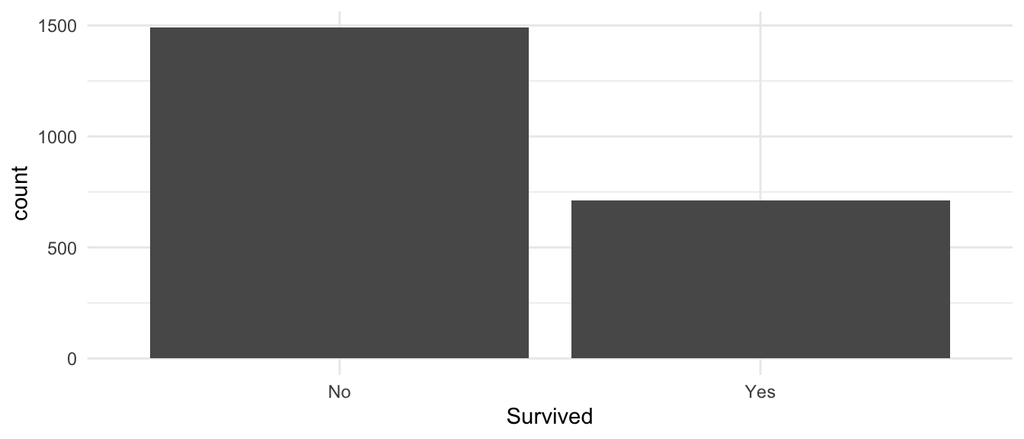

Figure 1: Bar chart

```r
ggplot(titanic, aes(x=Survived)) +
  geom_bar() +
  theme_minimal()
```

# Hypothesis Testing

**Two-Sided**

### Research Question

Do the passengers have a 50/50 chance of surviving?

### Hypothesis and Test Statistics

- $H_0:p=50\%$; proportions of surviving are equal.
- $H_a:p\ne50\%$; proportions of surviving are different.
- Significance level, $\alpha=5\%$.
- **chi-squared goodness of fit test**
- Success-failure condition is met.

### Results and Interpretation

The pie chart and test statistics is shown on Figure 2.

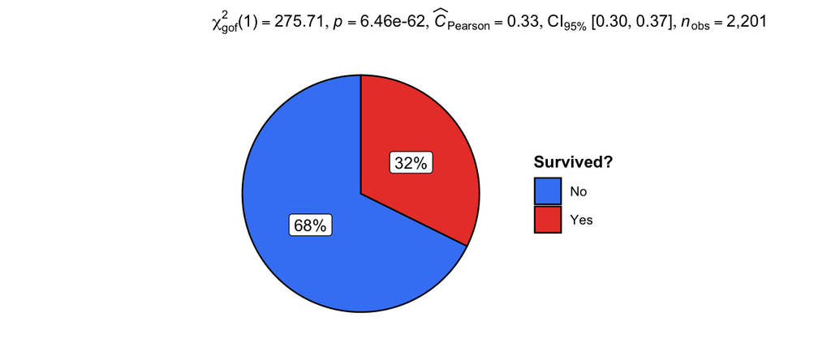

Figure 2: Pie chart and test statistics.

```r
ggpiestats(
  data = titanic,
  x = Survived,
  bf.message = FALSE,
  legend.title = "Survived?"
)
```

**One-Sided**

### Research Question

Is the survival rate less than the expected survival rate of 35%?

### Hypothesis and Test Statistics

- $H_0:p=35\%$; the survival rate is equal to the expected survival rate of 35%.
- $H_a:p<35\%$; the survival rate is less than the expected survival rate of 35%.
- Significance level, $\alpha=5\%$.
- **one proportion Z-test**
- Success-failure condition is met.

### Results and Interpretation

The test statistics is shown in Table 3.

```r
prop.test(
  x = 711, # number of successes
  n = 2201, # total number of trials (711 + 1490)
  p = 0.35,
  alternative = "less"
) |>
  tidy() |>
  select(estimate, statistic, p.value, method, alternative) |>
  mutate(across(where(is.numeric), ~ round(.x, 2))) |>
  kable()
```

Table 3: Test statistics.

| estimate | statistic | p.value | method | alternative |
| --- | --- | --- | --- | --- |
| 0.32 | 6.92 | 0 | 1-sample proportions test with continuity correction | less |

Based on the results and the *p*-value being lesser than 5% (*p*-value = 0.004), we reject the null hypothesis. There is strong evidence that the survival rate is less than the expected survival rate of 35%.